# MATH_6395_Homework_5_Brownian_Motion_Stochastic_process

## MATH 6395: Homework #5 - Brownian Motion stochastic process by Barry Daemi Southern Methodisit University October 3, 2022 $$\newcommand{\C}{\mathbb{C}} \newcommand{\R}{\mathbb{R}} \newcommand{\Z}{\mathbb{Z}} \newcommand{\Q}{\mathbb{Q}} \newcommand{\P}{\mathbb{P}} \newcommand{\F}{\mathbb{F}} \newcommand{\N}{\mathbb{N}} \newcommand{\E}{\mathbb{E}}$$

**Question 1**  
Implement algorithm 2.9.1 from book "Simulation and the Monte Carlo method" by Rubinstein, 3rd edition and generate 10 paths of Geometric Brownian motion.  
*solution:*

Imported the necessary python packages `numpy` and `matplotlib.pyplot`, so to compose a code script that generates a Geometric Brownian motion path over a period of 1 second with a sample of hundred thousand observed collisions.  
In the textbook titled, *Handbook of Monte Carlo Methods* by Dirk P. Kroese, Thomas Taimre and Zdravko I. Botev, there is a Geometric Brownian motion algorithm provided in MATLAB on pg. 197, which can be easily translated into a Python script. The following two code blocks is that very translation.

```python
import numpy as np
import matplotlib.pyplot as plt
```

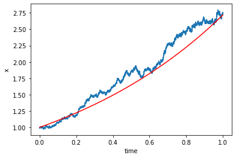

```python
T=1; n=100000; h=T/(n-1); t=np.linspace(0,T, num=n);
mu=1; sigma=0.2; x0=1;
W=np.sqrt(h)*np.cumsum(np.random.randn(n));
x=x0*np.exp((mu-sigma**2/2)*t+sigma*W);

plt.plot(t,x) # plot of Geometric Brownian Motion
plt.plot(t,np.exp(mu*t),'r') # Expected mean function plot
plt.xlabel("time")
plt.ylabel("x")
plt.show()
```

Now let simulate ten Brownian motion paths with the following algorithmic implementation.

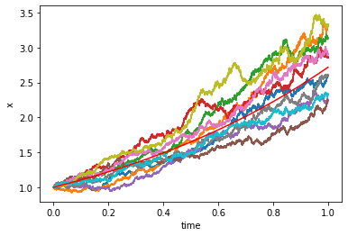

```python
for i in range(10):
    T=1; n=100000; h=T/(n-1); t=np.linspace(0,T, num=n);
    mu=1; sigma=0.2; x0=1;
    W=np.sqrt(h)*np.cumsum(np.random.randn(n));
    x=x0*np.exp((mu-sigma**2/2)*t+sigma*W);

    plt.plot(t,x) # plot of Geometric Brownian Motion

plt.plot(t,np.exp(mu*t),'r') # Expected mean function plot
plt.xlabel("time")
plt.ylabel("x")
plt.show()
```

Another algorithmic implementation of Brownian motion can be taken from *Simulation and The Monte Carlo Method, Third Edition*, by Reuven Y. Rybinstein and Dirk P. Kroese, from *Algoritm 2.9.1: Euler's Method for SDEs* on pg. 93. The algorithm is provided in pseudo-code, so one has to translate it into their own desired coding format, in our case our desired coding implementation format is a Python script. The following code block is that python script implementation.

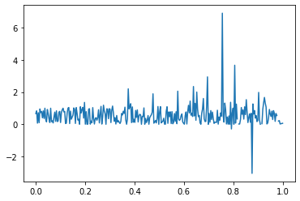

```python
T=1; n=300; h=T/(n-1); t=np.linspace(0,T, num=n);
mu=1; sigma=0.2; x0=1; a=0.5;b=0.5;

U1=np.random.uniform(0,1,n);
U2=np.random.uniform(0,1,n);
Y=np.random.beta(a, b, size=n);

for k in range(n):
    U1=np.random.uniform(0,1,n);
    U2=np.random.uniform(0,1,n);
    Z=np.sqrt(-2*np.log(U1))*np.sin(2*np.pi*U2);
    mu=np.mean(Z); sigma=np.std(Z);
    Y=Y+mu*Y*t*+sigma*np.sqrt(t)*Y*Z;

plt.plot(t,Y)
```

Let simulate ten Brownian motion with the following algorithmic implementation.

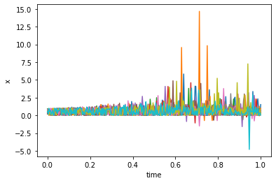

```python
for i in range(10):
    T=1; n=300; h=T/(n-1); t=np.linspace(0,T, num=n);
    mu=1; sigma=0.2; x0=1; a=0.5;b=0.5;

    U1=np.random.uniform(0,1,n);
    U2=np.random.uniform(0,1,n);
    Y=np.random.beta(a, b, size=n);

    for k in range(n):
        U1=np.random.uniform(0,1,n);
        U2=np.random.uniform(0,1,n);
        Z=np.sqrt(-2*np.log(U1))*np.sin(2*np.pi*U2);
        mu=np.mean(Z); sigma=np.std(Z);
        Y=Y+mu*Y*t*+sigma*np.sqrt(t)*Y*Z;

    plt.plot(t,Y)

plt.xlabel("time")
plt.ylabel("x")
plt.show()
```